# Mith74_3226

```python
import numpy as np
import pandas as pd

import warnings
warnings.filterwarnings('ignore')

pd.set_option('display.max_rows', None)
pd.set_option('display.max_columns', None)

from datetime import date
import datetime
from sklearn.preprocessing import StandardScaler
from category_encoders import OrdinalEncoder
from sklearn.preprocessing import LabelEncoder,OneHotEncoder
from sklearn.preprocessing import OneHotEncoder
from sklearn.impute import SimpleImputer
from sklearn.model_selection import train_test_split
from sklearn.pipeline import Pipeline,FeatureUnion
from sklearn.model_selection import GridSearchCV, cross_val_score, StratifiedKFold
from sklearn.compose import ColumnTransformer
from sklearn.base import BaseEstimator,TransformerMixin
from imblearn.over_sampling import SMOTE
from sklearn.pipeline import Pipeline,FeatureUnion
from sklearn.preprocessing import Imputer

from sklearn.model_selection import KFold
from sklearn.model_selection import cross_val_score
from sklearn.model_selection import GridSearchCV
from sklearn.metrics import classification_report

from sklearn.linear_model import LinearRegression,Lasso,Ridge
from sklearn.metrics import mean_squared_error,r2_score
from mlxtend.plotting import plot_learning_curves
from sklearn.ensemble import RandomForestRegressor
from sklearn.svm import SVR
from xgboost import XGBRegressor
from sklearn.neighbors import KNeighborsRegressor
from sklearn.tree import DecisionTreeRegressor
from sklearn.svm import SVR

from sklearn.tree import DecisionTreeClassifier
from sklearn.ensemble import RandomForestClassifier
from sklearn.svm import SVC
from sklearn.linear_model import LogisticRegression



import seaborn as sns
import matplotlib.pyplot as plt
%matplotlib inline
```

```python
def convert_to_cat(X_trn,X_tst,cols):
    X_trn[cols]=X_trn[cols].astype('category')
    X_tst[cols]=X_tst[cols].astype('category')
    return(X_trn,X_tst)

def inspect_data(data):
    return pd.DataFrame({"Data Type":data.dtypes,"No of Levels":data.apply(lambda x: x.nunique(),axis=0),"% of Unique Levels":data.apply(lambda x: 100*x.nunique()/len(x),axis=0), "Levels":data.apply(lambda x: str(x.unique()),axis=0)}).sort_values("% of Unique Levels", ascending=False)

def get_heatmap(data):
    fig, ax = plt.subplots(figsize=(10,10))
    sns.heatmap(data.corr(),linewidths=0.1,cmap='viridis',annot=True,ax=ax,annot_kws={"size": 12})
    plt.show()

def convert_obj_to_cat(X):
    X_cat_cols=X.columns[X.dtypes=='object'].tolist()
    X[X_cat_cols]=X[X_cat_cols].astype('category')
    return X


def convert_dtypes(X_trn,X_tst):
    X_trn=convert_obj_to_cat(X_trn)
    X_tst=convert_obj_to_cat(X_tst)
    return(X_trn,X_tst)

def get_cat_num_cols(X):
    X_cat_cols=X.columns[X.dtypes=='category'].tolist()
    X_num_cols=X.columns[~(X.dtypes=='category')].tolist()
    return (X_cat_cols,X_num_cols)

def show_cats_in_catcols(X_trn,X_tst,cat_col_list):
    for col in cat_col_list:
        labels = X_trn[col].astype('category').cat.categories.tolist()
        trn_labels=labels
        #print(labels)
        replace_map_comp = {col : {k: v for k,v in zip(labels,list(range(1,len(labels)+1)))}}
        #print(replace_map_comp)
        #print(replace_map_comp[col].keys())

        labels = X_tst[col].astype('category').cat.categories.tolist()
        tst_labels=labels
        missing=[]
        extra=[]
        extra=extra+[x for x in tst_labels if x not in trn_labels]
        missing=missing+[x for x in trn_labels if x not in tst_labels]
        #print(labels)
        print("---------------------------")
        print("Column=",col)
        print('missing in tst=',missing)
        print('missing in trn=',extra)
        print("---------------------------")
        labels=trn_labels+extra
        replace_map_comp = {col : {k: v for k,v in zip(labels,list(range(1,len(labels)+1)))}}
        #print(replace_map_comp)
        #print(replace_map_comp[col].keys())
        print('')


def get_box_plot(data,col1,col2):
    sns.boxplot(data[col1],data[col2])
    plt.show()

def get_dist_plot(data,col):
    sns.distplot(data[col])
    plt.show()

def get_scatter_plot(data,col1,col2):
    plt.scatter(data[col1],data[col2])
    plt.show()

def get_joint_plot(data,col1,col2):
    sns.jointplot(data[col1],data[col2])
    plt.show()

def mean_absolute_percentage_error(y_true, y_pred):
    return np.mean(np.abs((y_true - y_pred) / y_true)) * 100
```

```python
train_data=pd.read_excel('Train.xlsx')
test_data=pd.read_excel('Test.xlsx')

X_train_full=train_data.copy()
X_test = test_data.copy()
```

```python
X_train_full.dtypes
```

```
PropertyID                            object
Borough                                int64
State                                 object
Surroundings                          object
Address                               object
ZipCode                                int64
Block                                  int64
Lot                                    int64
BldgClassCategory                     object
NoOfResidentialUnits                   int64
NoOfCommercialUnits                    int64
TotalNoOfUnits                         int64
LandAreaInSqFt                         int64
GrossAreaInSqFt                        int64
YearOfConstruction                     int64
TaxClass_AtEvaluationTime              int64
BldgClass_AtEvaluationTime            object
DateOfEvaluation              datetime64[ns]
PropertyEvaluationvalue                int64
dtype: object
```

```python
X_test.dtypes
```

```
PropertyID                            object
Borough                                int64
State                                 object
Surroundings                          object
Address                               object
ZipCode                                int64
Block                                  int64
Lot                                    int64
BldgClassCategory                     object
NoOfResidentialUnits                   int64
NoOfCommercialUnits                    int64
TotalNoOfUnits                         int64
LandAreaInSqFt                         int64
GrossAreaInSqFt                        int64
YearOfConstruction                     int64
TaxClass_AtEvaluationTime              int64
BldgClass_AtEvaluationTime            object
DateOfEvaluation              datetime64[ns]
dtype: object
```

#### Converting object dtypes to category

```python
X_train_full,X_test=convert_dtypes(X_train_full,X_test)
X_train_full,X_test=convert_to_cat(X_train_full,X_test,['Borough','TaxClass_AtEvaluationTime'])
```

#### Distrubution of the PropertyEvaluationvalue is seemed right_skewed

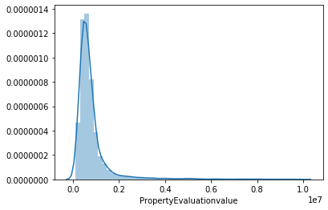

```python
sns.distplot(X_train_full.PropertyEvaluationvalue)
```

#### Univariate analysis on the numerical columns

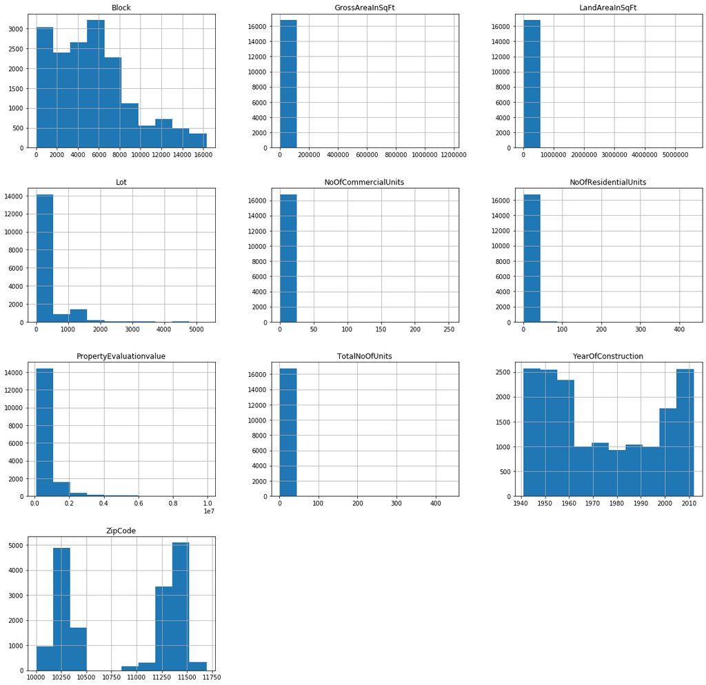

```python
X_train_full.hist(figsize=(20,20))
plt.show()
```

#### Get the list of category columns and numerical columns

```python
cat_col_list,num_col_list=get_cat_num_cols(X_train_full)
```

```python
print(cat_col_list)
print(num_col_list)
```

```
['PropertyID', 'Borough', 'State', 'Surroundings', 'Address', 'BldgClassCategory', 'TaxClass_AtEvaluationTime', 'BldgClass_AtEvaluationTime']
['ZipCode', 'Block', 'Lot', 'NoOfResidentialUnits', 'NoOfCommercialUnits', 'TotalNoOfUnits', 'LandAreaInSqFt', 'GrossAreaInSqFt', 'YearOfConstruction', 'DateOfEvaluation', 'PropertyEvaluationvalue']
```

#### Creating new columns like AgeOFProperty, DaysSinceDateofEvaluation, MonthOfEvaluation

#### -----------------------------------------------------------------------------------------------------------------------------------------

#### AgeOFProperty: This will give information about the property age till date

#### DaysSinceDateofEvaluation: This will give information about the the number of days its been since the date of evaluation

#### MonthOfEvaluation: This will give infomation of the Month when property was evaluated

```python
current_year = datetime.datetime.now().year #get current year
X_train_full['Current Year'] = datetime.datetime.now().year
X_train_full['AgeOfProperty']=X_train_full['Current Year']-X_train_full['YearOfConstruction']
X_train_full.drop(['Current Year'], axis=1, inplace=True)


X_train_full['today'] = date.today().strftime("%Y-%m-%d")
X_train_full['today'] = pd.to_datetime(X_train_full.today)
X_train_full['DaysSinceDateofEvaluation'] = (X_train_full.today - X_train_full['DateOfEvaluation']).astype('timedelta64[D]')
X_train_full.drop(['today'], axis=1, inplace=True)

X_train_full['MonthOfEvaluation'] = pd.DatetimeIndex(X_train_full['DateOfEvaluation']).month


current_year = datetime.datetime.now().year #get current year
X_test['Current Year'] = datetime.datetime.now().year
X_test['AgeOfProperty']=X_test['Current Year']-X_test['YearOfConstruction']
X_test.drop(['Current Year'], axis=1, inplace=True)

X_test['today'] = date.today().strftime("%Y-%m-%d")
X_test['today'] = pd.to_datetime(X_test.today)
X_test['DaysSinceDateofEvaluation'] = (X_test.today - X_test['DateOfEvaluation']).astype('timedelta64[D]')
X_test.drop(['today'], axis=1, inplace=True)

X_test['MonthOfEvaluation'] = pd.DatetimeIndex(X_test['DateOfEvaluation']).month
```

```python
X_train_full.shape,X_test.shape
```

```
((16810, 22), (2936, 21))
```

#### We see that the PropertyEvaluationvalue is actually similar accross all the months as the median Value of the PropertyEvaluationvalue is same in all the months. Also we can see that some kind of outlier

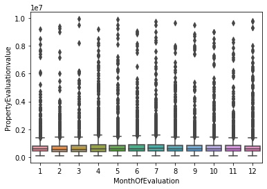

```python
sns.boxplot(x=X_train_full['MonthOfEvaluation'],y=X_train_full['PropertyEvaluationvalue'])
```

#### Viewing the Mean PropertyEvaluationvalue grouped by BldgClassCategory in ascending order

```python
pd.DataFrame(X_train_full.groupby(['BldgClassCategory'])['PropertyEvaluationvalue'].mean()).sort_values('PropertyEvaluationvalue',ascending=True)
```

| BldgClassCategory | PropertyEvaluationvalue |
| --- | --- |
| 25 LUXURY HOTELS | 1.281442e+05 |
| 45 CONDO HOTELS | 1.383320e+05 |
| 09 COOPS - WALKUP APARTMENTS | 1.921288e+05 |
| 42 CONDO CULTURAL/MEDICAL/EDUCATIONAL/ETC | 2.036500e+05 |
| 38 ASYLUMS AND HOMES | 2.099760e+05 |
| 10 COOPS - ELEVATOR APARTMENTS | 2.795187e+05 |
| 01 ONE FAMILY HOMES | 4.847993e+05 |
| 38 ASYLUMS AND HOMES | 4.999000e+05 |
| 41 TAX CLASS 4 - OTHER | 5.033333e+05 |
| 04 TAX CLASS 1 CONDOS | 5.129188e+05 |
| 02 TWO FAMILY HOMES | 5.434214e+05 |
| 12 CONDOS - WALKUP APARTMENTS | 5.486052e+05 |
| 05 TAX CLASS 1 VACANT LAND | 5.992378e+05 |
| 03 THREE FAMILY HOMES | 6.220397e+05 |
| 01 ONE FAMILY DWELLINGS | 6.422008e+05 |
| 44 CONDO PARKING | 7.480606e+05 |
| 02 TWO FAMILY DWELLINGS | 7.602622e+05 |
| 16 CONDOS - 2-10 UNIT WITH COMMERCIAL UNIT | 8.551070e+05 |
| 03 THREE FAMILY DWELLINGS | 9.857853e+05 |
| 35 INDOOR PUBLIC AND CULTURAL FACILITIES | 1.121000e+06 |
| 14 RENTALS - 4-10 UNIT | 1.266440e+06 |
| 37 RELIGIOUS FACILITIES | 1.302778e+06 |
| 15 CONDOS - 2-10 UNIT RESIDENTIAL | 1.346495e+06 |
| 07 RENTALS - WALKUP APARTMENTS | 1.423042e+06 |
| 13 CONDOS - ELEVATOR APARTMENTS | 1.424193e+06 |
| 29 COMMERCIAL GARAGES | 1.454140e+06 |
| 26 OTHER HOTELS | 1.504494e+06 |
| 14 RENTALS - 4-10 UNIT | 1.830884e+06 |
| 27 FACTORIES | 1.849018e+06 |
| 29 COMMERCIAL GARAGES | 1.880308e+06 |
| 41 TAX CLASS 4 - OTHER | 1.897475e+06 |
| 22 STORE BUILDINGS | 2.078951e+06 |
| 30 WAREHOUSES | 2.270782e+06 |
| 07 RENTALS - WALKUP APARTMENTS | 2.272617e+06 |
| 21 OFFICE BUILDINGS | 2.308065e+06 |
| 31 COMMERCIAL VACANT LAND | 2.361000e+06 |
| 21 OFFICE BUILDINGS | 2.441604e+06 |
| 30 WAREHOUSES | 2.513352e+06 |
| 33 EDUCATIONAL FACILITIES | 2.689567e+06 |
| 27 FACTORIES | 2.787534e+06 |
| 46 CONDO STORE BUILDINGS | 2.875101e+06 |
| 11A CONDO-RENTALS | 3.030000e+06 |
| 22 STORE BUILDINGS | 3.039536e+06 |
| 32 HOSPITAL AND HEALTH FACILITIES | 3.151799e+06 |
| 37 RELIGIOUS FACILITIES | 3.243667e+06 |
| 33 EDUCATIONAL FACILITIES | 3.313714e+06 |
| 32 HOSPITAL AND HEALTH FACILITIES | 4.266667e+06 |
| 08 RENTALS - ELEVATOR APARTMENTS | 4.349463e+06 |
| 35 INDOOR PUBLIC AND CULTURAL FACILITIES | 4.361250e+06 |
| 08 RENTALS - ELEVATOR APARTMENTS | 4.908070e+06 |
| 36 OUTDOOR RECREATIONAL FACILITIES | 6.050000e+06 |
| 26 OTHER HOTELS | 6.925000e+06 |

```python
order_index=list(pd.DataFrame(X_train_full.groupby(['BldgClassCategory'])['PropertyEvaluationvalue'].mean()).sort_values('PropertyEvaluationvalue',ascending=True).index)
```

#### But we see that there are many ourliers and so Mean is not a valid thing to use here

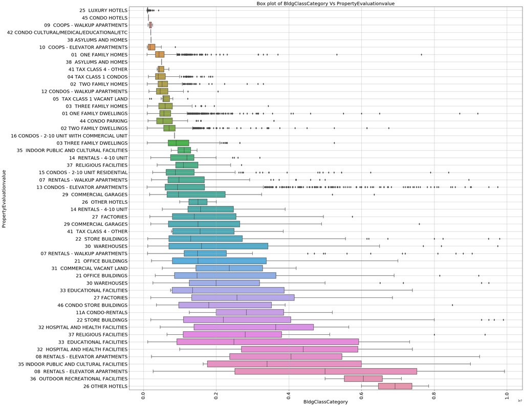

```python
fig, ax = plt.subplots(figsize = (30,30))
#sns.regplot(x = X_train_full[xcol],y = y_train_full['PropertyEvaluationvalue'],fit_reg= True)
#ns.boxplot(x=X_train_full_copy['BldgClassCategory'],y=X_train_full_copy['PropertyEvaluationvalue'],order=order_index)
sns.boxplot(y=X_train_full['BldgClassCategory'],x=X_train_full['PropertyEvaluationvalue'],order=order_index)
plt.title("Box plot of BldgClassCategory Vs PropertyEvaluationvalue",fontsize = 20)
xlabels=X_train_full['BldgClassCategory'].unique()
plt.xticks(x=X_train_full['BldgClassCategory'],rotation='vertical',fontsize=20)
plt.yticks(fontsize=20)
plt.xlabel('BldgClassCategory',fontsize = 20)
plt.ylabel('PropertyEvaluationvalue',fontsize = 20)
plt.grid()
plt.show()

#sns.boxplot(x=X_train_full_copy['BldgClassCategory'],y=X_train_full_copy['PropertyEvaluationvalue'])
```

#### Since mean is not suitable here and so Viewing the Median PropertyEvaluationvalue grouped by BldgClassCategory in ascending order

```python
order_index_median=list(pd.DataFrame(X_train_full.groupby(['BldgClassCategory'])['PropertyEvaluationvalue'].median()).sort_values('PropertyEvaluationvalue',ascending=True).index)
```

```python
pd.DataFrame(X_train_full.groupby(['BldgClassCategory'])['PropertyEvaluationvalue'].median()).sort_values('PropertyEvaluationvalue',ascending=True)
```

| BldgClassCategory | PropertyEvaluationvalue |
| --- | --- |
| 25 LUXURY HOTELS | 116285.5 |
| 45 CONDO HOTELS | 138332.0 |
| 10 COOPS - ELEVATOR APARTMENTS | 184000.0 |
| 09 COOPS - WALKUP APARTMENTS | 194257.5 |
| 42 CONDO CULTURAL/MEDICAL/EDUCATIONAL/ETC | 203650.0 |
| 38 ASYLUMS AND HOMES | 209976.0 |
| 04 TAX CLASS 1 CONDOS | 412500.0 |
| 01 ONE FAMILY HOMES | 430000.0 |
| 41 TAX CLASS 4 - OTHER | 435000.0 |
| 12 CONDOS - WALKUP APARTMENTS | 464000.0 |
| 38 ASYLUMS AND HOMES | 499900.0 |
| 02 TWO FAMILY HOMES | 510000.0 |
| 44 CONDO PARKING | 537636.0 |
| 05 TAX CLASS 1 VACANT LAND | 560000.0 |
| 01 ONE FAMILY DWELLINGS | 565000.0 |
| 03 THREE FAMILY HOMES | 595000.0 |
| 02 TWO FAMILY DWELLINGS | 710000.0 |
| 16 CONDOS - 2-10 UNIT WITH COMMERCIAL UNIT | 855107.0 |
| 15 CONDOS - 2-10 UNIT RESIDENTIAL | 880000.0 |
| 03 THREE FAMILY DWELLINGS | 900000.0 |
| 13 CONDOS - ELEVATOR APARTMENTS | 940000.0 |
| 29 COMMERCIAL GARAGES | 962500.0 |
| 07 RENTALS - WALKUP APARTMENTS | 980000.0 |
| 37 RELIGIOUS FACILITIES | 1100000.0 |
| 35 INDOOR PUBLIC AND CULTURAL FACILITIES | 1121000.0 |
| 14 RENTALS - 4-10 UNIT | 1200000.0 |
| 22 STORE BUILDINGS | 1300000.0 |
| 33 EDUCATIONAL FACILITIES | 1350000.0 |
| 27 FACTORIES | 1400000.0 |
| 21 OFFICE BUILDINGS | 1475000.0 |
| 07 RENTALS - WALKUP APARTMENTS | 1490000.0 |
| 21 OFFICE BUILDINGS | 1500000.0 |
| 29 COMMERCIAL GARAGES | 1500000.0 |
| 26 OTHER HOTELS | 1504493.5 |
| 41 TAX CLASS 4 - OTHER | 1562375.0 |
| 14 RENTALS - 4-10 UNIT | 1570000.0 |
| 30 WAREHOUSES | 1600000.0 |
| 46 CONDO STORE BUILDINGS | 1797802.5 |
| 30 WAREHOUSES | 2000000.0 |
| 22 STORE BUILDINGS | 2200000.0 |
| 31 COMMERCIAL VACANT LAND | 2361000.0 |
| 33 EDUCATIONAL FACILITIES | 2487500.0 |
| 27 FACTORIES | 2575000.0 |
| 37 RELIGIOUS FACILITIES | 2800000.0 |
| 11A CONDO-RENTALS | 2830000.0 |
| 35 INDOOR PUBLIC AND CULTURAL FACILITIES | 3400000.0 |
| 32 HOSPITAL AND HEALTH FACILITIES | 3641135.0 |
| 08 RENTALS - ELEVATOR APARTMENTS | 4060964.5 |
| 32 HOSPITAL AND HEALTH FACILITIES | 4400000.0 |
| 08 RENTALS - ELEVATOR APARTMENTS | 5000000.0 |
| 36 OUTDOOR RECREATIONAL FACILITIES | 6050000.0 |
| 26 OTHER HOTELS | 6925000.0 |

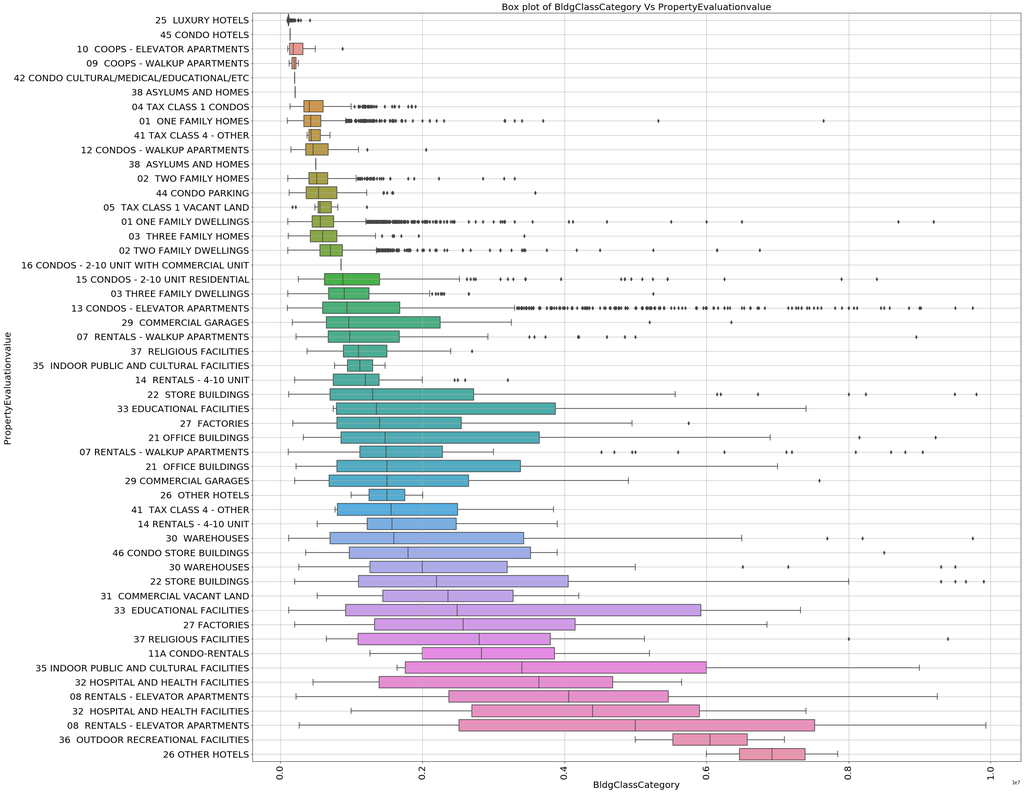

```python
fig, ax = plt.subplots(figsize = (30,30))
#sns.regplot(x = X_train_full[xcol],y = y_train_full['PropertyEvaluationvalue'],fit_reg= True)
#ns.boxplot(x=X_train_full_copy['BldgClassCategory'],y=X_train_full_copy['PropertyEvaluationvalue'],order=order_index)
sns.boxplot(y=X_train_full['BldgClassCategory'],x=X_train_full['PropertyEvaluationvalue'],order=order_index_median)
plt.title("Box plot of BldgClassCategory Vs PropertyEvaluationvalue",fontsize = 20)
xlabels=X_train_full['BldgClassCategory'].unique()
plt.xticks(x=X_train_full['BldgClassCategory'],rotation='vertical',fontsize=20)
plt.yticks(fontsize=20)
plt.xlabel('BldgClassCategory',fontsize = 20)
plt.ylabel('PropertyEvaluationvalue',fontsize = 20)
plt.grid()
plt.show()

#sns.boxplot(x=X_train_full_copy['BldgClassCategory'],y=X_train_full_copy['PropertyEvaluationvalue'])
```

#### Now we are grouping these based on the median values and creating separate classes by grouing them

```python
levels=[]
levels.append(order_index_median[0:6])
levels.append(order_index_median[6:17])
levels.append(order_index_median[17:26])
levels.append(order_index_median[26:37])
levels.append(order_index_median[37:45])
levels.append(order_index_median[45:50])
levels.append(order_index_median[50:52])
```

#### Created the below classes

```python
''' Class1
['25  LUXURY HOTELS',
 '45 CONDO HOTELS',
 '10  COOPS - ELEVATOR APARTMENTS',
 '09  COOPS - WALKUP APARTMENTS',
 '42 CONDO CULTURAL/MEDICAL/EDUCATIONAL/ETC',
 '38 ASYLUMS AND HOMES']
Class2
['04 TAX CLASS 1 CONDOS',
 '01  ONE FAMILY HOMES',
 '41 TAX CLASS 4 - OTHER',
 '12 CONDOS - WALKUP APARTMENTS',
 '38  ASYLUMS AND HOMES',
 '02  TWO FAMILY HOMES',
 '44 CONDO PARKING',
 '05  TAX CLASS 1 VACANT LAND',
 '01 ONE FAMILY DWELLINGS',
 '03  THREE FAMILY HOMES',
 '02 TWO FAMILY DWELLINGS']

 Class3
 ['16 CONDOS - 2-10 UNIT WITH COMMERCIAL UNIT',
 '15 CONDOS - 2-10 UNIT RESIDENTIAL',
 '03 THREE FAMILY DWELLINGS',
 '13 CONDOS - ELEVATOR APARTMENTS',
 '29  COMMERCIAL GARAGES',
 '07  RENTALS - WALKUP APARTMENTS',
 '37  RELIGIOUS FACILITIES',
 '35  INDOOR PUBLIC AND CULTURAL FACILITIES',
 '14  RENTALS - 4-10 UNIT']

 Class4
 ['22  STORE BUILDINGS',
 '33 EDUCATIONAL FACILITIES',
 '27  FACTORIES',
 '21 OFFICE BUILDINGS',
 '07 RENTALS - WALKUP APARTMENTS',
 '21  OFFICE BUILDINGS',
 '29 COMMERCIAL GARAGES',
 '26  OTHER HOTELS',
 '41  TAX CLASS 4 - OTHER',
 '14 RENTALS - 4-10 UNIT',
 '30  WAREHOUSES']

 Class5
 ['46 CONDO STORE BUILDINGS',
 '30 WAREHOUSES',
 '22 STORE BUILDINGS',
 '31  COMMERCIAL VACANT LAND',
 '33  EDUCATIONAL FACILITIES',
 '27 FACTORIES',
 '37 RELIGIOUS FACILITIES',
 '11A CONDO-RENTALS']

 Class6
 ['35 INDOOR PUBLIC AND CULTURAL FACILITIES',
 '32 HOSPITAL AND HEALTH FACILITIES',
 '08 RENTALS - ELEVATOR APARTMENTS',
 '32  HOSPITAL AND HEALTH FACILITIES',
 '08  RENTALS - ELEVATOR APARTMENTS']

 Class7
 ['36  OUTDOOR RECREATIONAL FACILITIES', '26 OTHER HOTELS']'''
```

```
" Class1\n['25  LUXURY HOTELS',\n '45 CONDO HOTELS',\n '10  COOPS - ELEVATOR APARTMENTS',\n '09  COOPS - WALKUP APARTMENTS',\n '42 CONDO CULTURAL/MEDICAL/EDUCATIONAL/ETC',\n '38 ASYLUMS AND HOMES']\nClass2\n['04 TAX CLASS 1 CONDOS',\n '01  ONE FAMILY HOMES',\n '41 TAX CLASS 4 - OTHER',\n '12 CONDOS …
```

```python
for i in list(range(len(levels))):
    x= dict.fromkeys(levels[i], 'Class'+str(i+1))
    X_train_full = X_train_full.replace(x)
    X_test=X_test.replace(x)
X_train_full,X_test=convert_to_cat(X_train_full,X_test,['BldgClassCategory'])
```

```python
X_train_full.shape,X_test.shape
```

```
((16810, 22), (2936, 21))
```

#### Creating Y_train and X_train

```python
y_train_full = X_train_full['PropertyEvaluationvalue']
X_train_full = X_train_full.copy().drop("PropertyEvaluationvalue",axis=1)
#y_train_full = X_train_full.filter(["PropertyEvaluationvalue"],axis=1)
```

#### Droping the belw columns as there many uniue values in them and also may be only one value

```python
X_train_full.drop(['State','Surroundings','Address','PropertyID','DateOfEvaluation','BldgClass_AtEvaluationTime'], axis=1, inplace=True)
X_test.drop(['State','Surroundings','Address','PropertyID','DateOfEvaluation','BldgClass_AtEvaluationTime'], axis=1, inplace=True)
```

```python
X_train_full.shape,X_test.shape,y_train_full.shape
```

```
((16810, 15), (2936, 15), (16810,))
```

```python
cat_cols_new,num_cols_new=get_cat_num_cols(X_train_full)
print(cat_cols_new)
print(num_cols_new)
```

```
['Borough', 'BldgClassCategory', 'TaxClass_AtEvaluationTime']
['ZipCode', 'Block', 'Lot', 'NoOfResidentialUnits', 'NoOfCommercialUnits', 'TotalNoOfUnits', 'LandAreaInSqFt', 'GrossAreaInSqFt', 'YearOfConstruction', 'AgeOfProperty', 'DaysSinceDateofEvaluation', 'MonthOfEvaluation']
```

```python
cat_cols_new,num_cols_new=get_cat_num_cols(X_test)
print(cat_cols_new)
print(num_cols_new)
```

```
['Borough', 'BldgClassCategory', 'TaxClass_AtEvaluationTime']
['ZipCode', 'Block', 'Lot', 'NoOfResidentialUnits', 'NoOfCommercialUnits', 'TotalNoOfUnits', 'LandAreaInSqFt', 'GrossAreaInSqFt', 'YearOfConstruction', 'AgeOfProperty', 'DaysSinceDateofEvaluation', 'MonthOfEvaluation']
```

#### We want to see whether the levels in the test and train datasets are same or not and we see that there is no Class7 in test data

```python
show_cats_in_catcols(X_train_full,X_test,cat_cols_new)
```

```
---------------------------
Column= Borough
missing in tst= []
missing in trn= []
---------------------------

---------------------------
Column= BldgClassCategory
missing in tst= ['Class7']
missing in trn= []
---------------------------

---------------------------
Column= TaxClass_AtEvaluationTime
missing in tst= []
missing in trn= []
---------------------------
```

```python
all_cols=cat_cols_new+num_cols_new
```

```python
print(all_cols)
```

```
['Borough', 'BldgClassCategory', 'TaxClass_AtEvaluationTime', 'ZipCode', 'Block', 'Lot', 'NoOfResidentialUnits', 'NoOfCommercialUnits', 'TotalNoOfUnits', 'LandAreaInSqFt', 'GrossAreaInSqFt', 'YearOfConstruction', 'AgeOfProperty', 'DaysSinceDateofEvaluation', 'MonthOfEvaluation']
```

#### Ordinal Encoding the classes

```python
mappings=[{'col':'BldgClassCategory','mapping':{'Class1': 1, 'Class2': 2, 'Class3': 3, 'Class4': 4, 'Class5': 5,
                                                'Class6': 6, 'Class7': 7}}
          ]

oe=OrdinalEncoder(mapping=mappings)

X_train_full=oe.fit_transform(X_train_full)
X_train_full=pd.DataFrame(X_train_full,columns=all_cols)
```

```python
X_test=oe.transform(X_test)
X_test=pd.DataFrame(X_test,columns=all_cols)
```

```python
X_train_full.tail()
```

|  | Borough | BldgClassCategory | TaxClass_AtEvaluationTime | ZipCode | Block | Lot | NoOfResidentialUnits | NoOfCommercialUnits | TotalNoOfUnits | LandAreaInSqFt | GrossAreaInSqFt | YearOfConstruction | AgeOfProperty | DaysSinceDateofEvaluation | MonthOfEvaluation |
| --- | --- | --- | --- | --- | --- | --- | --- | --- | --- | --- | --- | --- | --- | --- | --- |
| 16805 | 4 | 3 | 2 | 10007 | 123 | 1213 | 1 | 0 | 1 | 29715 | 2803 | 2004 | 15 | 1812.0 | 11 |
| 16806 | 4 | 3 | 2 | 10013 | 176 | 1054 | 1 | 0 | 1 | 12518 | 2252 | 2003 | 16 | 1793.0 | 12 |
| 16807 | 4 | 3 | 2 | 10013 | 176 | 1102 | 1 | 0 | 1 | 12518 | 2177 | 2003 | 16 | 1826.0 | 11 |
| 16808 | 4 | 3 | 2 | 10280 | 16 | 2249 | 1 | 0 | 1 | 12644 | 594 | 1981 | 38 | 1886.0 | 9 |
| 16809 | 4 | 6 | 2 | 10031 | 2065 | 22 | 16 | 1 | 17 | 4996 | 29529 | 2007 | 12 | 2430.0 | 3 |

```python
X_train_full.dtypes
```

```
Borough                      category
BldgClassCategory               int32
TaxClass_AtEvaluationTime    category
ZipCode                         int64
Block                           int64
Lot                             int64
NoOfResidentialUnits            int64
NoOfCommercialUnits             int64
TotalNoOfUnits                  int64
LandAreaInSqFt                  int64
GrossAreaInSqFt                 int64
YearOfConstruction              int64
AgeOfProperty                   int64
DaysSinceDateofEvaluation     float64
MonthOfEvaluation               int64
dtype: object
```

#### Creting Dummies

```python
X_train_full=pd.get_dummies(X_train_full,drop_first=True)
X_test=pd.get_dummies(X_test,drop_first=True)
```

```python
X_train_full.shape,X_test.shape
```

```
((16810, 19), (2936, 19))
```

```python
print(X_train_full.columns)
```

```
Index(['BldgClassCategory', 'ZipCode', 'Block', 'Lot', 'NoOfResidentialUnits',
       'NoOfCommercialUnits', 'TotalNoOfUnits', 'LandAreaInSqFt',
       'GrossAreaInSqFt', 'YearOfConstruction', 'AgeOfProperty',
       'DaysSinceDateofEvaluation', 'MonthOfEvaluation', 'Borough_2',
       'Borough_3', 'Borough_4', 'Borough_5', 'TaxClass_AtEvaluationTime_2',
       'TaxClass_AtEvaluationTime_4'],
      dtype='object')
```

```python
X_test.columns
```

```
Index(['BldgClassCategory', 'ZipCode', 'Block', 'Lot', 'NoOfResidentialUnits',
       'NoOfCommercialUnits', 'TotalNoOfUnits', 'LandAreaInSqFt',
       'GrossAreaInSqFt', 'YearOfConstruction', 'AgeOfProperty',
       'DaysSinceDateofEvaluation', 'MonthOfEvaluation', 'Borough_2',
       'Borough_3', 'Borough_4', 'Borough_5', 'TaxClass_AtEvaluationTime_2',
       'TaxClass_AtEvaluationTime_4'],
      dtype='object')
```

```python
y_train_full.shape
```

```
(16810,)
```

#### Train-test Split of the data

```python
X_train,X_val,y_train,y_val=train_test_split(X_train_full,y_train_full,test_size=0.1,random_state=333)
```

```python
num_cols_new=['ZipCode', 'Block', 'Lot', 'NoOfResidentialUnits', 'NoOfCommercialUnits', 'TotalNoOfUnits', 'LandAreaInSqFt',
              'GrossAreaInSqFt', 'YearOfConstruction', 'AgeOfProperty', 'DaysSinceDateofEvaluation', 'MonthOfEvaluation']

sc=StandardScaler()
X_train[num_cols_new]=sc.fit_transform(X_train[num_cols_new])

X_val[num_cols_new]=sc.transform(X_val[num_cols_new])

X_test[num_cols_new]=sc.transform(X_test[num_cols_new])
```

```python
print(X_train.shape,y_train.shape,X_val.shape,y_val.shape,X_test.shape)
```

[output not shown]

#### Random Forest Regression

```python
rf=RandomForestRegressor(criterion='mae')
rf.fit(X_train,y_train)
y_train_pred=rf.predict(X_train)
y_val_pred=rf.predict(X_val)
print("Train MAPE=",mean_absolute_percentage_error(y_train, y_train_pred))
print("Val MAPE=",mean_absolute_percentage_error(y_val, y_val_pred))
```

```
Train MAPE= 11.767546597452187
Val MAPE= 30.27800047348681
```

```python
y_test_pred=rf.predict(X_test)
```

```python
print(test_data.shape,X_test.shape)
```

```
(2936, 18) (2936, 19)
```

```python
output = pd.DataFrame({ 'PropertyID' : test_data['PropertyID'], 'PropertyEvaluationvalue': y_test_pred })
output.to_csv('submission.csv', index=False)
```

#### Support Vector Regressor with Gausian Kernel

```python
svr=SVR(kernel='rbf')
svr.fit(X_train,y_train)
y_train_pred=svr.predict(X_train)
y_val_pred=svr.predict(X_val)
print("Train MAPE=",mean_absolute_percentage_error(y_train, y_train_pred))
print("Val MAPE=",mean_absolute_percentage_error(y_val, y_val_pred))
```

```
Train MAPE= 49.48283322515534
Val MAPE= 48.24985254061078
```

#### Support Vector Regressor with Linear Kernel

```python
svr=SVR(kernel='linear')
svr.fit(X_train,y_train)
y_train_pred=svr.predict(X_train)
y_val_pred=svr.predict(X_val)
print("Train MAPE=",mean_absolute_percentage_error(y_train, y_train_pred))
print("Val MAPE=",mean_absolute_percentage_error(y_val, y_val_pred))
```

```
Train MAPE= 49.15906249484903
Val MAPE= 47.99586817472816
```

#### KNN Regressor

```python
knn=KNeighborsRegressor()
knn.fit(X_train,y_train)
y_train_pred=knn.predict(X_train)
y_val_pred=knn.predict(X_val)
print("Train MAPE=",mean_absolute_percentage_error(y_train, y_train_pred))
print("Val MAPE=",mean_absolute_percentage_error(y_val, y_val_pred))
```

```
Train MAPE= 29.734041639722747
Val MAPE= 41.11328670152166
```

#### XGB Regressor

```python
xg=XGBRegressor()
xg.fit(X_train,y_train)
y_train_pred=xg.predict(X_train)
y_val_pred=xg.predict(X_val)
print("Train MAPE=",mean_absolute_percentage_error(y_train, y_train_pred))
print("Val MAPE=",mean_absolute_percentage_error(y_val, y_val_pred))
```

```
[16:30:30] WARNING: C:/Jenkins/workspace/xgboost-win64_release_0.90/src/objective/regression_obj.cu:152: reg:linear is now deprecated in favor of reg:squarederror.
Train MAPE= 33.85227918624878
Val MAPE= 36.03501436154464
```

```python
y_test_pred=xg.predict(X_test)
```

```python
output = pd.DataFrame({ 'PropertyID' : test_data['PropertyID'], 'PropertyEvaluationvalue': y_test_pred })
output.to_csv('submission1.csv', index=False)
```

### Linear Regression

```python
lm=LinearRegression()
lm.fit(X_train,y_train)
y_train_pred=lm.predict(X_train)
y_val_pred=lm.predict(X_val)
print("Train MAPE=",mean_absolute_percentage_error(y_train, y_train_pred))
print("Val MAPE=",mean_absolute_percentage_error(y_val, y_val_pred))
```

```
Train MAPE= 54.47190552311044
Val MAPE= 54.83376167715242
```

#### Lasso Regression

```python
las=Lasso(alpha=.001)
las.fit(X_train,y_train)
y_train_pred=las.predict(X_train)
y_val_pred=las.predict(X_val)
print("Train MAPE=",mean_absolute_percentage_error(y_train, y_train_pred))
print("Val MAPE=",mean_absolute_percentage_error(y_val, y_val_pred))
```

```
Train MAPE= 54.531398220048466
Val MAPE= 54.888446745893724
```